# 第五章 词类和词性标注

## 本章目的

- 什么是词类，在自然语言处理中如何使用？
- 存储词语及词类的Python 数据结构是什么？
- 如何自动标注文本中词语的词类？

```python
%matplotlib inline
import nltk
from nltk import word_tokenize
```

### 词性和词性标注

使用词性标注器（part-of-speech tagger, POS tagger）处理词的序列，为每个词附加一个词性标记

```python
#无歧义
text = word_tokenize("And now for something completely different")
nltk.pos_tag(text)
```

```
[('And', 'CC'),
 ('now', 'RB'),
 ('for', 'IN'),
 ('something', 'NN'),
 ('completely', 'RB'),
 ('different', 'JJ')]
```

```python
#有歧义
text = word_tokenize("They refuse to permit us to obtain the refuse permit")
nltk.pos_tag(text)
```

```
[('They', 'PRP'),
 ('refuse', 'VBP'),
 ('to', 'TO'),
 ('permit', 'VB'),
 ('us', 'PRP'),
 ('to', 'TO'),
 ('obtain', 'VB'),
 ('the', 'DT'),
 ('refuse', 'NN'),
 ('permit', 'NN')]
```

### 词性标注器的作用

表征词语的用法，为结构分析服务

```python
text = nltk.Text(word.lower() for word in nltk.corpus.brown.words())
#搜索woman找到名词
text.similar('woman')
```

```
man day time year car moment world family house child boy country job
state war way girl place word question
```

```python
#搜索bought找到动词
text.similar('bought')
```

```
made done said put seen had found left given heard been got set
brought was that called told felt took
```

```python
#搜索over找到介词
text.similar('over')
```

```
in on to of and for with from at by that into as up out down through
is all about
```

```python
#搜索the找到限定词
text.similar('the')
```

```
a his this their its her an that our any all one these my in your no
some other and
```

### 表示已标注的标识符

已标注的标识符(tagged token)使用由标识符和标记组成的元组来表示

可以使用函数str2tuple()从表示已标注的标识符的标准字符串创建这样的元组

```python
tagged_token = nltk.tag.str2tuple('fly/NN')
tagged_token
```

```
('fly', 'NN')
```

```python
tagged_token[0]
```

```
'fly'
```

从字符串构造已标注标识符的列表

```python
sent =  '''
        The/AT grand/JJ jury/NN commented/VBD on/IN a/AT number/NN of/IN
        other/AP topics/NNS ,/, AMONG/IN them/PPO the/AT Atlanta/NP and/CC
        Fulton/NP-tl County/NN-tl purchasing/VBG departments/NNS which/WDT it/PPS
        said/VBD ``/`` ARE/BER well/QL operated/VBN and/CC follow/VB generally/RB
        accepted/VBN practices/NNS which/WDT inure/VB to/IN the/AT best/JJT
        interest/NN of/IN both/ABX governments/NNS ''/'' ./.
        '''
[nltk.tag.str2tuple(t) for t in sent.split()]
```

```
[('The', 'AT'),
 ('grand', 'JJ'),
 ('jury', 'NN'),
 ('commented', 'VBD'),
 ('on', 'IN'),
 ('a', 'AT'),
 ('number', 'NN'),
 ('of', 'IN'),
 ('other', 'AP'),
 ('topics', 'NNS'),
 (',', ','),
 ('AMONG', 'IN'),
 ('them', 'PPO'),
 ('the', 'AT'),
 ('Atlanta', 'NP'),
 ('and', 'CC'),
 ('Fulton', 'NP-TL'),
 ('County', 'NN-TL'),
 ('purchasing', 'VBG'),
 ('departments', 'NNS'),
 ('which', 'WDT'),
 ('it', 'PPS'),
 ('said', 'VBD'),
 ('``', '``'),
 ('ARE', 'BER'),
 ('well', 'QL'),
 ('operated', 'VBN'),
 ('and', 'CC'),
 ('follow', 'VB'),
 ('generally', 'RB'),
 ('accepted', 'VBN'),
 ('practices', 'NNS'),
 ('which', 'WDT'),
 ('inure', 'VB'),
 ('to', 'IN'),
 ('the', 'AT'),
 ('best', 'JJT'),
 ('interest', 'NN'),
 ('of', 'IN'),
 ('both', 'ABX'),
 ('governments', 'NNS'),
 ("''", "''"),
 ('.', '.')]
```

### 读取标注语料库

布朗库和词性映射

The/at Fulton/np-tl County/nn-tl Grand/jj-tl Jury/nn-tl said/vbd Friday/nr an/at investigation/nn of/in Atlanta's/np$ recent/jj primary/nn election/nn produced/vbd / no/at evidence/nn ''/'' that/cs any/dti irregularities/nns took/vbd place/nn ./.

```python
nltk.corpus.brown.tagged_words()
```

```
[('The', 'AT'), ('Fulton', 'NP-TL'), ...]
```

```python
print(nltk.corpus.nps_chat.tagged_words())
```

```
[('now', 'RB'), ('im', 'PRP'), ('left', 'VBD'), ...]
```

```python
nltk.corpus.conll2000.tagged_words()
```

```
[('Confidence', 'NN'), ('in', 'IN'), ('the', 'DT'), ...]
```

```python
nltk.corpus.treebank.tagged_words()
```

```
[('Pierre', 'NNP'), ('Vinken', 'NNP'), (',', ','), ...]
```

```python
nltk.corpus.brown.tagged_words(tagset='universal')
```

```
[('The', 'DET'), ('Fulton', 'NOUN'), ...]
```

```python
nltk.corpus.treebank.tagged_words(tagset='universal')
```

```
[('Pierre', 'NOUN'), ('Vinken', 'NOUN'), (',', '.'), ...]
```

```python
nltk.corpus.sinica_treebank.tagged_words()
```

```
[('一', 'Neu'), ('友情', 'Nad'), ('嘉珍', 'Nba'), ...]
```

### 常见词性

```python
from nltk.corpus import brown
brown_news_tagged = brown.tagged_words(categories='news', tagset='universal')
tag_fd = nltk.FreqDist(tag for (word, tag) in brown_news_tagged)
tag_fd.most_common()
```

```
[('NOUN', 30654),
 ('VERB', 14399),
 ('ADP', 12355),
 ('.', 11928),
 ('DET', 11389),
 ('ADJ', 6706),
 ('ADV', 3349),
 ('CONJ', 2717),
 ('PRON', 2535),
 ('PRT', 2264),
 ('NUM', 2166),
 ('X', 92)]
```

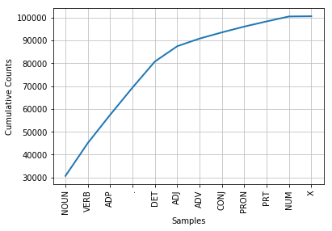

```python
tag_fd.plot(cumulative=True)
```

## 名词

名词：人物、地点、事件或概念

例子：女子、苏格兰、图书、情报

位置：限定词和形容词之后

功能：动词的主语或宾语

经常出现在名词之前的词性

```python
word_tag_pairs = nltk.bigrams(brown_news_tagged)
noun_preceders = [a[1] for (a, b) in word_tag_pairs if b[1] == 'NOUN']
fdist = nltk.FreqDist(noun_preceders)
[tag for (tag, _) in fdist.most_common()]
```

```
['NOUN',
 'DET',
 'ADJ',
 'ADP',
 '.',
 'VERB',
 'CONJ',
 'NUM',
 'ADV',
 'PRT',
 'PRON',
 'X']
```

#### 动词

动词：描述事件和行为的词语

例如：fall ，eat

动词在句中通常表示一个或多个名词短语之间的关系

新闻文本中最常见的动词

```python
wsj = nltk.corpus.treebank.tagged_words(tagset='universal')
word_tag_fd = nltk.FreqDist(wsj)
[wt[0] for (wt, _) in word_tag_fd.most_common() if wt[1] == 'VERB']
```

```
['is',
 'said',
 'was',
 'are',
 'be',
 'has',
 'have',
 'will',
 'says',
 'would',
 'were',
 'had',
 'been',
 'could',
 "'s",
 'can',
 'do',
 'say',
 'make',
 'may',
 'did',
 'rose',
 'made',
 'does',
 'expected',
 'buy',
 'take',
 'get',
 'might',
 'sell',
 'added',
 'help',
 'sold',
 'including',
 'should',
 'reported',
 'according',
 'compared',
 'pay',
 'being',
```

[output cut: 946 more lines]

```
 'stressing',
 'Think',
 'contributing',
 'pegged',
 'bribed',
 'commit',
 'signing',
 'Founded',
 'diminished',
 'skyrocketed',
 'asserted',
 'specializes',
 'establish',
 'recover',
 ...]
```

### 关于词性的条件频率表

给定词，按频率降序输出词性列表

```python
cfd1 = nltk.ConditionalFreqDist(wsj)
cfd1['yield'].most_common()
```

```
[('VERB', 28), ('NOUN', 20)]
```

```python
cfd1['cut'].most_common()
```

```
[('VERB', 25), ('NOUN', 3)]
```

给定词性，按频率降序输出词语列表

```python
wsj = nltk.corpus.treebank.tagged_words()
cfd2 = nltk.ConditionalFreqDist((tag, word) for (word, tag) in wsj)
list(cfd2['VBN'].most_common())
```

```
[('been', 150),
 ('expected', 52),
 ('made', 33),
 ('compared', 32),
 ('based', 31),
 ('priced', 26),
 ('used', 26),
 ('sold', 25),
 ('named', 20),
 ('designed', 20),
 ('fined', 18),
 ('held', 18),
 ('taken', 16),
 ('paid', 15),
 ('traded', 15),
 ('increased', 14),
 ('said', 14),
 ('disclosed', 13),
 ('reached', 13),
 ('called', 13),
 ('filed', 13),
 ('scheduled', 13),
 ('set', 12),
 ('known', 12),
 ('estimated', 12),
 ('proposed', 12),
 ('reported', 12),
 ('built', 11),
 ('approved', 11),
 ('acquired', 11),
 ('given', 11),
 ('offered', 10),
 ('received', 10),
 ('found', 10),
 ('aimed', 9),
 ('prepared', 9),
 ('preferred', 9),
 ('issued', 9),
 ('required', 9),
 ('considered', 9),
```

[output cut: 637 more lines]

```
 ('learned', 1),
 ('Related', 1),
 ('attempted', 1),
 ('chilled', 1),
 ('prohibited', 1),
 ('feared', 1),
 ('imposed', 1),
 ('codified', 1),
 ('slated', 1),
 ('obligated', 1),
 ('heated', 1),
 ('tracked', 1),
 ('afflicted', 1),
 ('plagued', 1),
 ('Concerned', 1)]
```

可以同是VD（过去式）和VN（过去分词）的词

```python
cfd1 = nltk.ConditionalFreqDist(wsj)
[w for w in cfd1.conditions() if 'VBD' in cfd1[w] and 'VBN' in cfd1[w]]
```

```
['heard',
 'offered',
 'speculated',
 'snapped',
 'preferred',
 'reflected',
 'hampered',
 'worked',
 'decided',
 'awarded',
 'introduced',
 'edged',
 'squeezed',
 'retired',
 'accused',
 'favored',
 'surged',
 'noted',
 'triggered',
 'viewed',
 'fueled',
 'expanded',
 'provided',
 'halted',
 'dropped',
 'jumped',
 'accelerated',
 'dismissed',
 'marketed',
 'invented',
 'plunged',
 'earned',
 'reached',
 'carried',
 'invested',
 'secured',
 'led',
 'deemed',
 'obligated',
 'lent',
```

[output cut: 206 more lines]

```
 'limited',
 'bought',
 'announced',
 'contained',
 'built',
 'collapsed',
 'filed',
 'settled',
 'read',
 'said',
 'managed',
 'forecast',
 'finished',
 'gained',
 'removed']
```

```python
idx1 = wsj.index(('kicked', 'VBD'))
wsj[idx1-4:idx1+1]
```

```
[('While', 'IN'),
 ('program', 'NN'),
 ('trades', 'NNS'),
 ('swiftly', 'RB'),
 ('kicked', 'VBD')]
```

```python
idx2 = wsj.index(('kicked', 'VBN'))
wsj[idx2-4:idx2+1]
```

```
[('head', 'NN'),
 ('of', 'IN'),
 ('state', 'NN'),
 ('has', 'VBZ'),
 ('kicked', 'VBN')]
```

## 形容词和副词

形容词

- 修饰名词
- 可以作为修饰语，如：the large pizza ，或表语，如：the pizza is large
- 可以有内部结构，如：the falling stocks 中的fall+ing 副词
- 修饰动词
- - 指定由动词表示的事件的时间、方式、地点或趋势，如：the stocks fell quickly 可以修饰形容词，如：Mary’s teacher was really nice

### 未简化的标记

找出最频繁的名词标记

名词NN的变种：含有$的名词所有格,含有S的复数名词，含有P的专有名词

后缀修饰符：-NC表示引用，-HL表示标题中的词，-TL表示标题

```python
def findtags(tag_prefix, tagged_text):
    cfd = nltk.ConditionalFreqDist((tag, word) for (word, tag) in tagged_text
                                  if tag.startswith(tag_prefix))
    return dict((tag, cfd[tag].most_common(5)) for tag in cfd.conditions())
tagdict = findtags('NN', nltk.corpus.brown.tagged_words(categories='news'))
for tag in sorted(tagdict):
    print(tag, tagdict[tag])
```

```
NN [('year', 137), ('time', 97), ('state', 88), ('week', 85), ('home', 72)]
NN$ [("year's", 13), ("world's", 8), ("state's", 7), ("city's", 6), ("company's", 6)]
NN$-HL [("Navy's", 1), ("Golf's", 1)]
NN$-TL [("President's", 11), ("Army's", 3), ("University's", 3), ("Administration's", 3), ("League's", 3)]
NN-HL [('sp.', 2), ('Salary', 2), ('business', 2), ('war', 2), ('condition', 2)]
NN-NC [('ova', 1), ('eva', 1), ('aya', 1)]
NN-TL [('President', 88), ('House', 68), ('State', 59), ('University', 42), ('Dr.', 41)]
NN-TL-HL [('Fort', 2), ('Mayor', 1), ('Street', 1), ('City', 1), ('Dr.', 1)]
NNS [('years', 101), ('members', 69), ('people', 52), ('sales', 51), ('men', 46)]
NNS$ [("children's", 7), ("women's", 5), ("janitors'", 3), ("men's", 3), ("taxpayers'", 2)]
NNS$-HL [("Idols'", 1), ("Dealers'", 1)]
NNS$-TL [("Women's", 4), ("States'", 3), ("Giants'", 2), ("Officers'", 1), ("Writers'", 1)]
NNS-HL [('principles', 1), ('centers', 1), ('relations', 1), ('bobbles', 1), ('Police', 1)]
NNS-TL [('States', 38), ('Nations', 11), ('Masters', 10), ('Bears', 9), ('Rules', 9)]
NNS-TL-HL [('Nations', 1)]
```

### 查找标记的解释

```python
nltk.help.upenn_tagset('JJ')
```

```
JJ: adjective or numeral, ordinal
    third ill-mannered pre-war regrettable oiled calamitous first separable
    ectoplasmic battery-powered participatory fourth still-to-be-named
    multilingual multi-disciplinary ...
```

### 探索已标注的语料库

查看跟在often 后面的词语

```python
brown_learned_text = brown.words(categories='learned')
sorted(set(b for (a, b) in nltk.bigrams(brown_learned_text) if a == 'often'))
```

```
[',',
 '.',
 'accomplished',
 'analytically',
 'appear',
 'apt',
 'associated',
 'assuming',
 'became',
 'become',
 'been',
 'began',
 'call',
 'called',
 'carefully',
 'chose',
 'classified',
 'colorful',
 'composed',
 'contain',
 'differed',
 'difficult',
 'encountered',
 'enough',
 'equate',
 'extremely',
 'found',
 'happens',
 'have',
 'ignored',
 'in',
 'involved',
 'more',
 'needed',
 'nightly',
 'observed',
 'of',
 'on',
 'out',
 'quite',
 'represent',
 'responsible',
 'revamped',
 'seclude',
 'set',
 'shortened',
 'sing',
 'sounded',
 'stated',
 'still',
 'sung',
 'supported',
 'than',
 'to',
 'when',
 'work']
```

查看跟在often 后面的词的词性

```python
brown_lrnd_tagged = brown.tagged_words(categories='learned', tagset='universal')
tags = [b[1] for (a, b) in nltk.bigrams(brown_lrnd_tagged) if a[0] == 'often']
fd = nltk.FreqDist(tags)
fd.tabulate()
```

```
VERB  ADV  ADP  ADJ    .  PRT
  37    8    7    6    4    2
```

查找多词性的词

```python
brown_news_tagged = brown.tagged_words(categories='news', tagset='universal')
data = nltk.ConditionalFreqDist((word.lower(), tag)
                                for (word, tag) in brown_news_tagged)
for word in sorted(data.conditions()):
    if len(data[word]) > 3:
        tags = [tag for (tag, _) in data[word].most_common()]
        print(word, ' '.join(tags))
```

```
best ADJ NOUN VERB ADV
close ADV ADJ VERB NOUN
open ADJ VERB NOUN ADV
present ADJ ADV NOUN VERB
that ADP DET PRON ADV
```

### Python词典

(word, tag)是词到标记的映射

在Python 中最自然的存储映射的方式是词典(dictionary)数据类型

### 列表 vs 词典

列表查找：使用下标索引

[figure not shown]

词典查询：使用关键字，如人名、域名或单词

[figure not shown]

词典的别名：映射（map）、哈希映射（hashmap）、哈希（hash）、关联数组（associative array）

### Python 词典

Python 词典数据类型可用来做任意类型之间的映射

例子：定义pos为空词典，然后添加4个词条，指定某些词的词性。使用方括号将词条添加到词典

```python
pos = {}
pos
```

```
{}
```

```python
pos['colorless'] = 'ADJ'
pos
```

```
{'colorless': 'ADJ'}
```

```python
pos['ideas'] = 'N'
pos['sleep'] = 'V'
pos['furiously'] = 'ADV'
pos
```

```
{'colorless': 'ADJ', 'furiously': 'ADV', 'ideas': 'N', 'sleep': 'V'}
```

使用键来检索值

```python
pos['colorless']
```

```
'ADJ'
```

```python
pos['green']
```

```
---------------------------------------------------------------------------
KeyError                                  Traceback (most recent call last)
<ipython-input-36-7a088695b94e> in <module>()
----> 1 pos['green']

KeyError: 'green'
```

键的查找：将词典转换成列表，或在需要使用列表的地方使用词典, 或用在for 循环中

```python
list(pos)
```

```
['furiously', 'colorless', 'ideas', 'sleep']
```

```python
sorted(pos)
```

```
['colorless', 'furiously', 'ideas', 'sleep']
```

```python
[w for w in pos if w.endswith('s')]
```

```
['colorless', 'ideas']
```

词典方法keys()、values()和items()允许访问作为单独的列表的键、值以及键-值对

```python
list(pos.keys())
```

```
['furiously', 'colorless', 'ideas', 'sleep']
```

```python
list(pos.values())
```

```
['ADV', 'ADJ', 'N', 'V']
```

```python
list(pos.items())
```

```
[('furiously', 'ADV'), ('colorless', 'ADJ'), ('ideas', 'N'), ('sleep', 'V')]
```

```python
for key, val in sorted(pos.items()):
    print(key + ":", val)
```

```
colorless: ADJ
furiously: ADV
ideas: N
sleep: V
```

#### 定义词典

使用键-值对格式创建词典

词典的键必须是不可改变的类型，如字符串和元组

```python
pos = {'colorless': 'ADJ', 'ideas': 'N', 'sleep': 'V', 'furiously': 'ADV'}
pos = dict(colorless='ADJ', ideas='N', sleep='V', furiously='ADV')
pos
```

```
{'colorless': 'ADJ', 'furiously': 'ADV', 'ideas': 'N', 'sleep': 'V'}
```

#### 默认词典

Defaultdict：为新键自动创建条目并赋予默认值

```python
from collections import defaultdict
frequency = defaultdict(int)
frequency['colorless'] = 4
frequency['ideas']
```

```
0
```

```python
pos = defaultdict(list)
pos['sleep'] = ['NOUN', 'VERB']
pos['ideas']
```

```
[]
```

创建一个默认值是‘Noun’的词典。当访问一个不存在的条目时，它会自动添加到字典

```python
pos = defaultdict(lambda: 'NOUN')
pos['colorless'] = 'ADJ'
pos['blog']
```

```
'NOUN'
```

```python
list(pos.items())
```

```
[('blog', 'NOUN'), ('colorless', 'ADJ')]
```

### 利用默认词典处理未登录词

创建默认词典，映射每个词到替换词。

最频繁的n个词将被映射到它们自己。其他的被映射到UNK （out of vocabulary）

```python
alice = nltk.corpus.gutenberg.words('carroll-alice.txt')
vocab = nltk.FreqDist(alice)
v1000 = [word for (word, _) in vocab.most_common(1000)]
mapping = defaultdict(lambda: 'UNK')
for v in v1000:
    mapping[v] = v
alice2 = [mapping[v] for v in alice]
alice2[:100]
```

```
['UNK',
 'Alice',
 "'",
 's',
 'UNK',
 'in',
 'UNK',
 'by',
 'UNK',
 'UNK',
 'UNK',
 'UNK',
 'CHAPTER',
 'I',
 '.',
 'Down',
 'the',
 'Rabbit',
 '-',
 'UNK',
 'Alice',
 'was',
 'beginning',
 'to',
 'get',
 'very',
 'tired',
 'of',
 'sitting',
 'by',
 'her',
 'sister',
 'on',
 'the',
 'bank',
 ',',
 'and',
 'of',
 'having',
 'nothing',
```

[output cut: 45 more lines]

```
 'So',
 'she',
 'was',
 'considering',
 'in',
 'her',
 'own',
 'mind',
 '(',
 'as',
 'well',
 'as',
 'she',
 'could',
 ',']
```

### 增量式更新词典

递增地更新字典，按值排序

```python
counts = defaultdict(int)
from nltk.corpus import brown
for (word, tag) in brown.tagged_words(categories='news', tagset='universal'):
    counts[tag] += 1
```

```python
from operator import itemgetter
sorted(counts.items(), key=itemgetter(1), reverse=True)
```

```
[('NOUN', 30654),
 ('VERB', 14399),
 ('ADP', 12355),
 ('.', 11928),
 ('DET', 11389),
 ('ADJ', 6706),
 ('ADV', 3349),
 ('CONJ', 2717),
 ('PRON', 2535),
 ('PRT', 2264),
 ('NUM', 2166),
 ('X', 92)]
```

sorted()的第一个参数是要排序的项目（由POS 标记和频率组成的元组）列表

sorted()的第二个参数使用函数itemgetter()指定排序键

itemgetter(n)，返回一个函数，这个函数可以被其他序列对象调用获得这个序列的第n 个元素

```python
[t for t, c in sorted(counts.items(), key=itemgetter(1), reverse=True)]
```

```
['NOUN',
 'VERB',
 'ADP',
 '.',
 'DET',
 'ADJ',
 'ADV',
 'CONJ',
 'PRON',
 'PRT',
 'NUM',
 'X']
```

#### 创建anagram词典

```python
words = nltk.corpus.words.words('en')
anagrams = defaultdict(list)
for word in words:
    key = ''.join(sorted(word))
    anagrams[key].append(word)
anagrams['aeilnrt']
```

```
['entrail', 'latrine', 'ratline', 'reliant', 'retinal', 'trenail']
```

等价形式：nltk.Index()

```python
anagrams = nltk.Index((''.join(sorted(w)), w) for w in words)
anagrams['aeilnrt']
```

```
['entrail', 'latrine', 'ratline', 'reliant', 'retinal', 'trenail']
```

### 倒排词典

给定值查找对应的键

```python
counts = defaultdict(int)
for word in nltk.corpus.gutenberg.words('milton-paradise.txt'):
    counts[word] += 1
[key for (key, value) in counts.items() if value == 32]
```

```
['King',
 'Against',
 'mortal',
 'thine',
 'virtue',
 'Him',
 'been',
 'every',
 'brought',
 'There']
```

便捷的反向查找：建立一个映射值到键的词典

一一对应的情况

```python
pos = {'colorless': 'ADJ', 'ideas': 'N', 'sleep': 'V', 'furiously': 'ADV'}
pos2 = dict((value, key) for (key, value) in pos.items())
pos2['N']
```

```
'ideas'
```

一对多的情况

```python
pos.update({'cats': 'N', 'scratch': 'V', 'peacefully': 'ADV', 'old': 'ADJ'})
pos2 = defaultdict(list)
for key, value in pos.items():
    pos2[value].append(key)
pos2['ADV']
```

```
['furiously', 'peacefully']
```

便捷的方法：采用nltk.Index

```python
pos2 = nltk.Index((value, key) for (key, value) in pos.items())
pos2['ADV']
```

```
['furiously', 'peacefully']
```

## 自动标注

- 默认标注器
- 正则表达式标注器
- 查表标注器

```python
from nltk.corpus import brown
brown_tagged_sents = brown.tagged_sents(categories='news')
brown_sents = brown.sents(categories='news')
```

brown_tagged_sents是人工标注的句子（正确答案，或称为金标准, gold standard）

brown_sent是未标记的句子

当标注器对给定词猜测的标记与金标准相同，标注器被视为正确

### 默认标注器

为每个词语分配相同的词性标记，用最有可能（概率最大）的词性标注每个词

精度太低！

```python
tags = [tag for (word, tag) in brown.tagged_words(categories='news')]
nltk.FreqDist(tags).max()
```

```
'NN'
```

```python
raw = 'I do not like green eggs and ham, I do not like them Sam I am!'
tokens = word_tokenize(raw)
default_tagger = nltk.DefaultTagger('NN')
default_tagger.tag(tokens)
```

```
[('I', 'NN'),
 ('do', 'NN'),
 ('not', 'NN'),
 ('like', 'NN'),
 ('green', 'NN'),
 ('eggs', 'NN'),
 ('and', 'NN'),
 ('ham', 'NN'),
 (',', 'NN'),
 ('I', 'NN'),
 ('do', 'NN'),
 ('not', 'NN'),
 ('like', 'NN'),
 ('them', 'NN'),
 ('Sam', 'NN'),
 ('I', 'NN'),
 ('am', 'NN'),
 ('!', 'NN')]
```

```python
default_tagger.evaluate(brown_tagged_sents)
```

```
0.13089484257215028
```

### 正则表达式标注器

基于匹配模式分配词性标记给词语

```python
patterns = [
    (r'.*ing$', 'VBG'),               # gerunds
    (r'.*ed$', 'VBD'),                # simple past
    (r'.*es$', 'VBZ'),                # 3rd singular present
    (r'.*ould$', 'MD'),               # modals
    (r'.*\'s$', 'NN$'),               # possessive nouns
    (r'.*s$', 'NNS'),                 # plural nouns
    (r'^-?[0-9]+(.[0-9]+)?$', 'CD'),  # cardinal numbers
    (r'.*', 'NN')                     # nouns (default)
    ]
regexp_tagger = nltk.RegexpTagger(patterns)
regexp_tagger.tag(brown_sents[3])
```

```
[('``', 'NN'),
 ('Only', 'NN'),
 ('a', 'NN'),
 ('relative', 'NN'),
 ('handful', 'NN'),
 ('of', 'NN'),
 ('such', 'NN'),
 ('reports', 'NNS'),
 ('was', 'NNS'),
 ('received', 'VBD'),
 ("''", 'NN'),
 (',', 'NN'),
 ('the', 'NN'),
 ('jury', 'NN'),
 ('said', 'NN'),
 (',', 'NN'),
 ('``', 'NN'),
 ('considering', 'VBG'),
 ('the', 'NN'),
 ('widespread', 'NN'),
 ('interest', 'NN'),
 ('in', 'NN'),
 ('the', 'NN'),
 ('election', 'NN'),
 (',', 'NN'),
 ('the', 'NN'),
 ('number', 'NN'),
 ('of', 'NN'),
 ('voters', 'NNS'),
 ('and', 'NN'),
 ('the', 'NN'),
 ('size', 'NN'),
 ('of', 'NN'),
 ('this', 'NNS'),
 ('city', 'NN'),
 ("''", 'NN'),
 ('.', 'NN')]
```

```python
regexp_tagger.evaluate(brown_tagged_sents)
```

```
0.20326391789486245
```

### 查表标注器

找出100个最频繁的词，存储它们最可能的词性标记，作为“查表标注器”，之后构建UnigramTagger

```python
from nltk.corpus import brown
fd = nltk.FreqDist(brown.words(categories='news'))
cfd = nltk.ConditionalFreqDist(brown.tagged_words(categories='news'))
most_freq_words = fd.most_common(100)
likely_tags = dict((word, cfd[word].max()) for (word, _) in most_freq_words)
baseline_tagger = nltk.UnigramTagger(model=likely_tags)
baseline_tagger.evaluate(brown_tagged_sents)
```

```
0.45578495136941344
```

```python
sents = brown.sents(categories='news')[3]
baseline_tagger.tag(sents)
```

```
[('``', '``'),
 ('Only', None),
 ('a', 'AT'),
 ('relative', None),
 ('handful', None),
 ('of', 'IN'),
 ('such', None),
 ('reports', None),
 ('was', 'BEDZ'),
 ('received', None),
 ("''", "''"),
 (',', ','),
 ('the', 'AT'),
 ('jury', None),
 ('said', 'VBD'),
 (',', ','),
 ('``', '``'),
 ('considering', None),
 ('the', 'AT'),
 ('widespread', None),
 ('interest', None),
 ('in', 'IN'),
 ('the', 'AT'),
 ('election', None),
 (',', ','),
 ('the', 'AT'),
 ('number', None),
 ('of', 'IN'),
 ('voters', None),
 ('and', 'CC'),
 ('the', 'AT'),
 ('size', None),
 ('of', 'IN'),
 ('this', 'DT'),
 ('city', None),
 ("''", "''"),
 ('.', '.')]
```

#### 回退

回退：先使用查表标注，如果找不到对应的条目再使用默认标注器

是自动标注的一种重要思想

实现：通过指定一个标注器作为另一个标注器的参数

```python
baseline_tagger = nltk.UnigramTagger(model=likely_tags,
                                     backoff=nltk.DefaultTagger('NN'))
```

```python
baseline_tagger.evaluate(brown_tagged_sents)
```

```
0.5817769556656125
```

#### 查表标注器的性能

用不同大小的模型建立查表标注器

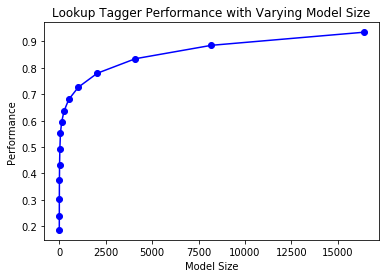

```python
def performance(cfd, wordlist):
    lt = dict((word, cfd[word].max()) for word in wordlist)
    baseline_tagger = nltk.UnigramTagger(model=lt, backoff=nltk.DefaultTagger('NN'))
    return baseline_tagger.evaluate(brown.tagged_sents(categories='news'))

def display():
    import pylab
    word_freqs = nltk.FreqDist(brown.words(categories='news')).most_common()
    words_by_freq = [w for (w, _) in word_freqs]
    cfd = nltk.ConditionalFreqDist(brown.tagged_words(categories='news'))
    sizes = 2 ** pylab.arange(15)
    perfs = [performance(cfd, words_by_freq[:size]) for size in sizes]
    pylab.plot(sizes, perfs, '-bo')
    pylab.title('Lookup Tagger Performance with Varying Model Size')
    pylab.xlabel('Model Size')
    pylab.ylabel('Performance')
    pylab.show()
display()
```

### N-gram 标注器

#### 一元标注器

对每个词语分配最有可能的标记

```python
sents = brown.tagged_sents(categories='news')
brown_sents = brown.sents(categories='news')
unigram_tagger = nltk.UnigramTagger(brown_tagged_sents)
unigram_tagger.tag(brown_sents[2007])
```

```
[('Various', 'JJ'),
 ('of', 'IN'),
 ('the', 'AT'),
 ('apartments', 'NNS'),
 ('are', 'BER'),
 ('of', 'IN'),
 ('the', 'AT'),
 ('terrace', 'NN'),
 ('type', 'NN'),
 (',', ','),
 ('being', 'BEG'),
 ('on', 'IN'),
 ('the', 'AT'),
 ('ground', 'NN'),
 ('floor', 'NN'),
 ('so', 'QL'),
 ('that', 'CS'),
 ('entrance', 'NN'),
 ('is', 'BEZ'),
 ('direct', 'JJ'),
 ('.', '.')]
```

```python
unigram_tagger.evaluate(brown_tagged_sents)
```

```
0.9349006503968017
```

上述结果是否可靠? -- 封闭测试

#### 分离训练和测试数据

```python
size = int(len(brown_tagged_sents) * 0.9)
size
```

```
4160
```

```python
train_sents = brown_tagged_sents[:size]
test_sents = brown_tagged_sents[size:]
unigram_tagger = nltk.UnigramTagger(train_sents)
unigram_tagger.evaluate(test_sents)
```

```
0.8120203329014253
```

以上称为开放测试 -- 更加可靠

#### N元标注器

挑选在给定的上下文中最有可能的标记，其上下文是当前词和它前面n-1个词的词性标记

示例: 三元标注器

[figure not shown]

未设置回退功能的N元标注器

```python
bigram_tagger = nltk.BigramTagger(train_sents)
bigram_tagger.tag(brown_sents[2007])
```

```
[('Various', 'JJ'),
 ('of', 'IN'),
 ('the', 'AT'),
 ('apartments', 'NNS'),
 ('are', 'BER'),
 ('of', 'IN'),
 ('the', 'AT'),
 ('terrace', 'NN'),
 ('type', 'NN'),
 (',', ','),
 ('being', 'BEG'),
 ('on', 'IN'),
 ('the', 'AT'),
 ('ground', 'NN'),
 ('floor', 'NN'),
 ('so', 'CS'),
 ('that', 'CS'),
 ('entrance', 'NN'),
 ('is', 'BEZ'),
 ('direct', 'JJ'),
 ('.', '.')]
```

```python
unseen_sent = brown_sents[4203]
bigram_tagger.tag(unseen_sent)
```

```
[('The', 'AT'),
 ('population', 'NN'),
 ('of', 'IN'),
 ('the', 'AT'),
 ('Congo', 'NP'),
 ('is', 'BEZ'),
 ('13.5', None),
 ('million', None),
 (',', None),
 ('divided', None),
 ('into', None),
 ('at', None),
 ('least', None),
 ('seven', None),
 ('major', None),
 ('``', None),
 ('culture', None),
 ('clusters', None),
 ("''", None),
 ('and', None),
 ('innumerable', None),
 ('tribes', None),
 ('speaking', None),
 ('400', None),
 ('separate', None),
 ('dialects', None),
 ('.', None)]
```

```python
bigram_tagger.evaluate(test_sents)
```

```
0.10305990232233629
```

效果不好的原因：未在训练语料中出现的上下文太多了

#### 组合标注器

组合bigram 、unigram 和默认标注器

```python
t0 = nltk.DefaultTagger('NN')
t1 = nltk.UnigramTagger(train_sents, backoff=t0)
t2 = nltk.BigramTagger(train_sents, backoff=t1)
t2.evaluate(test_sents)
```

```
0.8461078441144224
```

#### 存储标注器

目的：将标注器训练得到的参数存入文件，以便将来直接读入

```python
from pickle import dump
output = open('t2.pkl', 'wb')
dump(t2, output, -1)
output.close()
from pickle import load
input = open('t2.pkl', 'rb')
tagger = load(input)
input.close()
```

```python
text = """The board's action shows what free enterprise
    is up against in our complex maze of regulatory laws ."""
tokens = text.split()
tagger.tag(tokens)
```

```
[('The', 'AT'),
 ("board's", 'NN$'),
 ('action', 'NN'),
 ('shows', 'NNS'),
 ('what', 'WDT'),
 ('free', 'JJ'),
 ('enterprise', 'NN'),
 ('is', 'BEZ'),
 ('up', 'RP'),
 ('against', 'IN'),
 ('in', 'IN'),
 ('our', 'PP$'),
 ('complex', 'JJ'),
 ('maze', 'NN'),
 ('of', 'IN'),
 ('regulatory', 'NN'),
 ('laws', 'NNS'),
 ('.', '.')]
```

### 性能限制

性能上限：标注歧义的出现概率

```python
cfd = nltk.ConditionalFreqDist(((x[1], y[1], z[0]), z[1])
            for sent in brown_tagged_sents
            for x, y, z in nltk.trigrams(sent))
ambiguous_contexts = [c for c in cfd.conditions() if len(cfd[c]) > 1]
sum(cfd[c].N() for c in ambiguous_contexts) / cfd.N()
```

```
0.049297702068029296
```

混淆矩阵

```python
test_tags = [tag for sent in brown.sents(categories='editorial')
             for (word, tag) in t2.tag(sent)]
gold_tags = [tag for (word, tag) in brown.tagged_words(categories='editorial')]
print(nltk.ConfusionMatrix(gold_tags, test_tags))
```

```
           |                                                                                                                                                                                                                                                                                                …
           |                                                                                                                                                                                                                                                                                                …
           |                                                                                                                                                                                                                                                                                                …
           |                                                                                                                                                                                                                                                                                                …
           |                                                                                         A                                                                                              B    B              B    B                                                                              …
           |                                                 -                                       B                   A    A         A    A         B              B                             E    E              E    E         C    C         C    C         C              D    D                  …
           |                             *         ,         -         .         :    :              N                   P    P         T    T         E         B    E                        B    R    R         B    Z    Z         C    C         D    D         S              O    O         D        …
           |                             -         -         -         -         -    -    A    A    -    A         A    -    -         -    -         -    B    E    D    B    B    B    B    E    -    -    B    E    -    -         -    -         -    -         -         D    -    -    D    O    D   …
           |         '                   H         H    -    H         H         H    T    B    B    T    B    A    P    H    T    A    H    T    B    H    E    D    Z    E    E    E    E    R    H    T    E    Z    H    T    C    H    T    C    H    T    C    H    D    O    H    T    O    D    O   …
           |    '    '    (    )    *    L    ,    L    -    L    .    L    :    L    L    L    N    L    X    P    $    L    L    T    L    L    E    L    D    Z    *    G    M    N    R    *    L    L    Z    *    L    L    C    L    L    D    L    L    S    L    O    *    L    L    D    *    Z   …
-----------+------------------------------------------------------------------------------------------------------------------------------------------------------------------------------------------------------------------------------------------------------------------------------------------------…
         ' |  <19>   .    .    .    .    .    .    .    .    .    .    .    .    .    .    .    .    .    .    .    .    .    .    .    .    .    .    .    .    .    .    .    .    .    .    .    .    .    .    .    .    .    .    .    .    .    .    .    .    .    .    .    .    .    .    .    .   …
        '' |    . <382>   .    .    .    .    .    .    .    .    .    .    .    .    .    .    .    .    .    .    .    .    .    .    .    .    .    .    .    .    .    .    .    .    .    .    .    .    .    .    .    .    .    .    .    .    .    .    .    .    .    .    .    .    .    .    .   …
         ( |    .    .  <95>   .    .    .    .    .    .    .    .    .    .    .    .    .    .    .    .    .    .    .    .    .    .    .    .    .    .    .    .    .    .    .    .    .    .    .    .    .    .    .    .    .    .    .    .    .    .    .    .    .    .    .    .    .    .   …
         ) |    .    .    .  <95>   .    .    .    .    .    .    .    .    .    .    .    .    .    .    .    .    .    .    .    .    .    .    .    .    .    .    .    .    .    .    .    .    .    .    .    .    .    .    .    .    .    .    .    .    .    .    .    .    .    .    .    .    .   …
         * |    .    .    .    . <304>   .    .    .    .    .    .    .    .    .    .    .    .    .    .    .    .    .    .    .    .    .    .    .    .    .    .    .    .    .    .    .    .    .    .    .    .    .    .    .    .    .    .    .    .    .    .    .    .    .    .    .    .   …
      *-HL |    .    .    .    .    3   <.>   .    .    .    .    .    .    .    .    .    .    .    .    .    .    .    .    .    .    .    .    .    .    .    .    .    .    .    .    .    .    .    .    .    .    .    .    .    .    .    .    .    .    .    .    .    .    .    .    .    .    .   …
```

[output cut: 203 more lines]

### 训练自带的标注器

Trigrams'n'Tags

```python
from nltk.corpus import treebank
train_data=treebank.tagged_sents()[:3000]
test_data=treebank.tagged_sents()[3000:]
from nltk.tag import tnt
tnt_pos_tagger=tnt.TnT()
tnt_pos_tagger.train(train_data)
tnt_pos_tagger.evaluate(test_data)
```

```
0.875674508957479
```

## 如何确定词的词类

语言学家使用形态学、句法和语义线索确定词类

- 形态学：词缀，动词和名词的变化形式等
- 句法：词语所处的上下文. 例如，形容词可以立即出现在一个名词前，或紧跟在词be 或very 后
- 语义：词的意义对其词类是一个有用的线索. 例如：名词的一种定义 ：一个人、地方或事物的名称